# Communicate Data Findings - Ford GoBike System

## Preliminary Wrangling

> In this step I am going to gather and load the data into the notebook then I will understand and assess the dataset using both visually and programmatic methods.

### Data Gathering

> Loading the data and storing it on a dataframe

```python
# import all packages and set plots to be embedded inline
import numpy as np
import pandas as pd
import matplotlib.pyplot as plt
import seaborn as sb
import datetime as dt
%matplotlib inline
```

```python
df = pd.read_csv('201902-fordgobike-tripdata.csv') #Creating a new dataframe to load the dataset in it
```

### Data Assessment

> Assessing the dataset both visually and programmatically

```python
df.sample(5) #Visually assessing a sample of the data
```

|  | duration_sec | start_time | end_time | start_station_id | start_station_name | start_station_latitude | start_station_longitude | end_station_id | end_station_name | end_station_latitude | end_station_longitude | bike_id | user_type | member_birth_year | member_gender | bike_share_for_all_trip |
| --- | --- | --- | --- | --- | --- | --- | --- | --- | --- | --- | --- | --- | --- | --- | --- | --- |
| 44280 | 4409 | 2019-02-22 13:59:18.3980 | 2019-02-22 15:12:47.7710 | 21.0 | Montgomery St BART Station (Market St at 2nd St) | 37.789625 | -122.400811 | 21.0 | Montgomery St BART Station (Market St at 2nd St) | 37.789625 | -122.400811 | 2702 | Subscriber | 1983.0 | Male | No |
| 10915 | 525 | 2019-02-27 19:23:12.0570 | 2019-02-27 19:31:57.3070 | 245.0 | Downtown Berkeley BART | 37.870139 | -122.268422 | 256.0 | Hearst Ave at Euclid Ave | 37.875112 | -122.260553 | 4664 | Subscriber | 1996.0 | Male | No |
| 62699 | 548 | 2019-02-20 16:33:00.7190 | 2019-02-20 16:42:09.2770 | 386.0 | 24th St at Bartlett St | 37.752105 | -122.419724 | 137.0 | Jersey St at Castro St | 37.750506 | -122.433950 | 4741 | Subscriber | 1971.0 | Male | No |
| 42650 | 271 | 2019-02-22 17:25:24.4240 | 2019-02-22 17:29:55.4700 | 104.0 | 4th St at 16th St | 37.767045 | -122.390833 | 91.0 | Berry St at King St | 37.771762 | -122.398438 | 5554 | Subscriber | 1990.0 | Female | No |
| 35481 | 1000 | 2019-02-23 18:18:26.6350 | 2019-02-23 18:35:06.8820 | 109.0 | 17th St at Valencia St | 37.763316 | -122.421904 | 124.0 | 19th St at Florida St | 37.760447 | -122.410807 | 6366 | Customer | 1985.0 | Female | No |

```python
df.shape #Checking the number of rows and columns
```

```
(183412, 16)
```

```python
df.info() #General properties of the attributes
```

```
<class 'pandas.core.frame.DataFrame'>
RangeIndex: 183412 entries, 0 to 183411
Data columns (total 16 columns):
 #   Column                   Non-Null Count   Dtype
---  ------                   --------------   -----
 0   duration_sec             183412 non-null  int64
 1   start_time               183412 non-null  object
 2   end_time                 183412 non-null  object
 3   start_station_id         183215 non-null  float64
 4   start_station_name       183215 non-null  object
 5   start_station_latitude   183412 non-null  float64
 6   start_station_longitude  183412 non-null  float64
 7   end_station_id           183215 non-null  float64
 8   end_station_name         183215 non-null  object
 9   end_station_latitude     183412 non-null  float64
 10  end_station_longitude    183412 non-null  float64
 11  bike_id                  183412 non-null  int64
 12  user_type                183412 non-null  object
 13  member_birth_year        175147 non-null  float64
 14  member_gender            175147 non-null  object
 15  bike_share_for_all_trip  183412 non-null  object
dtypes: float64(7), int64(2), object(7)
memory usage: 22.4+ MB
```

```python
df.describe() #General description of the data
```

|  | duration_sec | start_station_id | start_station_latitude | start_station_longitude | end_station_id | end_station_latitude | end_station_longitude | bike_id | member_birth_year |
| --- | --- | --- | --- | --- | --- | --- | --- | --- | --- |
| count | 183412.000000 | 183215.000000 | 183412.000000 | 183412.000000 | 183215.000000 | 183412.000000 | 183412.000000 | 183412.000000 | 175147.000000 |
| mean | 726.078435 | 138.590427 | 37.771223 | -122.352664 | 136.249123 | 37.771427 | -122.352250 | 4472.906375 | 1984.806437 |
| std | 1794.389780 | 111.778864 | 0.099581 | 0.117097 | 111.515131 | 0.099490 | 0.116673 | 1664.383394 | 10.116689 |
| min | 61.000000 | 3.000000 | 37.317298 | -122.453704 | 3.000000 | 37.317298 | -122.453704 | 11.000000 | 1878.000000 |
| 25% | 325.000000 | 47.000000 | 37.770083 | -122.412408 | 44.000000 | 37.770407 | -122.411726 | 3777.000000 | 1980.000000 |
| 50% | 514.000000 | 104.000000 | 37.780760 | -122.398285 | 100.000000 | 37.781010 | -122.398279 | 4958.000000 | 1987.000000 |
| 75% | 796.000000 | 239.000000 | 37.797280 | -122.286533 | 235.000000 | 37.797320 | -122.288045 | 5502.000000 | 1992.000000 |
| max | 85444.000000 | 398.000000 | 37.880222 | -121.874119 | 398.000000 | 37.880222 | -121.874119 | 6645.000000 | 2001.000000 |

```python
df.duplicated().sum() #Checking for duplicates
```

```
0
```

```python
df.isnull().sum() #Checking for null values
```

```
duration_sec                  0
start_time                    0
end_time                      0
start_station_id            197
start_station_name          197
start_station_latitude        0
start_station_longitude       0
end_station_id              197
end_station_name            197
end_station_latitude          0
end_station_longitude         0
bike_id                       0
user_type                     0
member_birth_year          8265
member_gender              8265
bike_share_for_all_trip       0
dtype: int64
```

```python
df.user_type.unique()
```

```
array(['Customer', 'Subscriber'], dtype=object)
```

#### What is the structure of your dataset?

> The dataset conatins the details of 183412 trips with 16 attributes which are:

-Trip Duration (seconds) -Start Time and Date -End Time and Date -Start Station ID -Start Station Name -Start Station Latitude -Start Station Longitude -End Station ID -End Station Name -End Station Latitude -End Station Longitude -Bike ID -User Type (Subscriber or Customer – “Subscriber” = Member or “Customer” = Casual or one day) -Member Year of Birth -Member Gender -bike share program (tracks members who are enrolled in the Bike Share for All program for low-income residents)

#### What is/are the main feature(s) of interest in your dataset?

> I am intrested in finding insights on gender, type, time, and duration.

#### What features in the dataset do you think will help support your investigation into your feature(s) of interest?

> I beleive adding the following features will assisst me in the exploration :  
> -Duration in minutes  
> -Start day  
> -Start hour  
> -Member Age

### Data Cleaning

> This step includes cleaning the and prepare it for analysis

```python
df_clean=df.copy() #Creating a copy of the dataframe to perform cleaning steps
```

#### - Removing null values

#### Define

Dropping the rows that contain null values

#### Code

```python
df_clean=df_clean.dropna()
```

#### Test

```python
df_clean.isnull().sum()
```

```
duration_sec               0
start_time                 0
end_time                   0
start_station_id           0
start_station_name         0
start_station_latitude     0
start_station_longitude    0
end_station_id             0
end_station_name           0
end_station_latitude       0
end_station_longitude      0
bike_id                    0
user_type                  0
member_birth_year          0
member_gender              0
bike_share_for_all_trip    0
dtype: int64
```

#### - Converting start time to DateTime format

#### Define

Changing the format of the start time attributes from object to DateTime

#### Code

```python
df_clean['start_time'] = pd.to_datetime(df_clean['start_time'])
```

#### Test

```python
df_clean.head()
```

|  | duration_sec | start_time | end_time | start_station_id | start_station_name | start_station_latitude | start_station_longitude | end_station_id | end_station_name | end_station_latitude | end_station_longitude | bike_id | user_type | member_birth_year | member_gender | bike_share_for_all_trip |
| --- | --- | --- | --- | --- | --- | --- | --- | --- | --- | --- | --- | --- | --- | --- | --- | --- |
| 0 | 52185 | 2019-02-28 17:32:10.145 | 2019-03-01 08:01:55.9750 | 21.0 | Montgomery St BART Station (Market St at 2nd St) | 37.789625 | -122.400811 | 13.0 | Commercial St at Montgomery St | 37.794231 | -122.402923 | 4902 | Customer | 1984.0 | Male | No |
| 2 | 61854 | 2019-02-28 12:13:13.218 | 2019-03-01 05:24:08.1460 | 86.0 | Market St at Dolores St | 37.769305 | -122.426826 | 3.0 | Powell St BART Station (Market St at 4th St) | 37.786375 | -122.404904 | 5905 | Customer | 1972.0 | Male | No |
| 3 | 36490 | 2019-02-28 17:54:26.010 | 2019-03-01 04:02:36.8420 | 375.0 | Grove St at Masonic Ave | 37.774836 | -122.446546 | 70.0 | Central Ave at Fell St | 37.773311 | -122.444293 | 6638 | Subscriber | 1989.0 | Other | No |
| 4 | 1585 | 2019-02-28 23:54:18.549 | 2019-03-01 00:20:44.0740 | 7.0 | Frank H Ogawa Plaza | 37.804562 | -122.271738 | 222.0 | 10th Ave at E 15th St | 37.792714 | -122.248780 | 4898 | Subscriber | 1974.0 | Male | Yes |
| 5 | 1793 | 2019-02-28 23:49:58.632 | 2019-03-01 00:19:51.7600 | 93.0 | 4th St at Mission Bay Blvd S | 37.770407 | -122.391198 | 323.0 | Broadway at Kearny | 37.798014 | -122.405950 | 5200 | Subscriber | 1959.0 | Male | No |

#### - Adding star day and hour columns

#### Define

Decompose the start_time column into two individual columns which are day and hour.

#### Code

```python
df_clean['start_day'] = df_clean['start_time'].dt.strftime('%a')
df_clean['start_hour'] = df_clean['start_time'].dt.hour
```

#### Test

```python
df_clean.head()
```

|  | duration_sec | start_time | end_time | start_station_id | start_station_name | start_station_latitude | start_station_longitude | end_station_id | end_station_name | end_station_latitude | end_station_longitude | bike_id | user_type | member_birth_year | member_gender | bike_share_for_all_trip | start_day | start_hour |
| --- | --- | --- | --- | --- | --- | --- | --- | --- | --- | --- | --- | --- | --- | --- | --- | --- | --- | --- |
| 0 | 52185 | 2019-02-28 17:32:10.145 | 2019-03-01 08:01:55.9750 | 21.0 | Montgomery St BART Station (Market St at 2nd St) | 37.789625 | -122.400811 | 13.0 | Commercial St at Montgomery St | 37.794231 | -122.402923 | 4902 | Customer | 1984.0 | Male | No | Thu | 17 |
| 2 | 61854 | 2019-02-28 12:13:13.218 | 2019-03-01 05:24:08.1460 | 86.0 | Market St at Dolores St | 37.769305 | -122.426826 | 3.0 | Powell St BART Station (Market St at 4th St) | 37.786375 | -122.404904 | 5905 | Customer | 1972.0 | Male | No | Thu | 12 |
| 3 | 36490 | 2019-02-28 17:54:26.010 | 2019-03-01 04:02:36.8420 | 375.0 | Grove St at Masonic Ave | 37.774836 | -122.446546 | 70.0 | Central Ave at Fell St | 37.773311 | -122.444293 | 6638 | Subscriber | 1989.0 | Other | No | Thu | 17 |
| 4 | 1585 | 2019-02-28 23:54:18.549 | 2019-03-01 00:20:44.0740 | 7.0 | Frank H Ogawa Plaza | 37.804562 | -122.271738 | 222.0 | 10th Ave at E 15th St | 37.792714 | -122.248780 | 4898 | Subscriber | 1974.0 | Male | Yes | Thu | 23 |
| 5 | 1793 | 2019-02-28 23:49:58.632 | 2019-03-01 00:19:51.7600 | 93.0 | 4th St at Mission Bay Blvd S | 37.770407 | -122.391198 | 323.0 | Broadway at Kearny | 37.798014 | -122.405950 | 5200 | Subscriber | 1959.0 | Male | No | Thu | 23 |

#### - Adding age column

#### Define

Adding age column by calculating the age from the date

#### Code

```python
df_clean['member_age'] = df_clean['start_time'].dt.year - df_clean['member_birth_year']
```

#### Test

```python
df_clean.member_age.value_counts()
```

```
31.0     10214
26.0      9323
30.0      8967
29.0      8640
28.0      8484
         ...
91.0         1
89.0         1
109.0        1
141.0        1
92.0         1
Name: member_age, Length: 75, dtype: int64
```

#### - Removing age outliers

#### Define

Removing age outliers which are the values greater than 80

#### Code

```python
index = df_clean[(df_clean['member_age'] > 80)|(df_clean['member_age'] < 18)].index
df_clean.drop(index, inplace=True)
```

#### Test

```python
df_clean.member_age.value_counts()
```

```
31.0    10214
26.0     9323
30.0     8967
29.0     8640
28.0     8484
        ...
77.0       21
73.0       19
80.0       11
78.0        9
75.0        2
Name: member_age, Length: 62, dtype: int64
```

#### - Converting Duration from sec to min

#### Define

Converting Duration from sec to min by /60

#### Code

```python
df_clean['duration_sec']=df_clean['duration_sec']/60
df_clean.rename(columns={"duration_sec": "duration_min"}, inplace=True)
```

#### Test

```python
df_clean.info()
```

```
<class 'pandas.core.frame.DataFrame'>
Int64Index: 174760 entries, 0 to 183411
Data columns (total 19 columns):
 #   Column                   Non-Null Count   Dtype
---  ------                   --------------   -----
 0   duration_min             174760 non-null  float64
 1   start_time               174760 non-null  datetime64[ns]
 2   end_time                 174760 non-null  object
 3   start_station_id         174760 non-null  float64
 4   start_station_name       174760 non-null  object
 5   start_station_latitude   174760 non-null  float64
 6   start_station_longitude  174760 non-null  float64
 7   end_station_id           174760 non-null  float64
 8   end_station_name         174760 non-null  object
 9   end_station_latitude     174760 non-null  float64
 10  end_station_longitude    174760 non-null  float64
 11  bike_id                  174760 non-null  int64
 12  user_type                174760 non-null  object
 13  member_birth_year        174760 non-null  float64
 14  member_gender            174760 non-null  object
 15  bike_share_for_all_trip  174760 non-null  object
 16  start_day                174760 non-null  object
 17  start_hour               174760 non-null  int64
 18  member_age               174760 non-null  float64
dtypes: datetime64[ns](1), float64(9), int64(2), object(7)
memory usage: 26.7+ MB
```

#### - Removing unnecessary columns

#### Define

Dropping the columns that I do not need in the analysis

#### Code

```python
df_clean = df_clean.drop(['start_time','end_time','start_station_id','start_station_name','start_station_latitude','start_station_longitude','end_station_id','end_station_name','end_station_latitude','end_station_longitude','bike_id','member_birth_year','bike_share_for_all_trip'], axis = 1)
```

#### Test

```python
df_clean.info()
```

```
<class 'pandas.core.frame.DataFrame'>
Int64Index: 174760 entries, 0 to 183411
Data columns (total 6 columns):
 #   Column         Non-Null Count   Dtype
---  ------         --------------   -----
 0   duration_min   174760 non-null  float64
 1   user_type      174760 non-null  object
 2   member_gender  174760 non-null  object
 3   start_day      174760 non-null  object
 4   start_hour     174760 non-null  int64
 5   member_age     174760 non-null  float64
dtypes: float64(2), int64(1), object(3)
memory usage: 9.3+ MB
```

> Storing the final clean dataset into a csv file

```python
df_clean.to_csv('GoBike_clean.csv',encoding='utf-8-sig')
```

## Data Exploration

### Univariate Exploration

> This is the simplest form of exploration where the data being analyzed contains only one variable. The main purpose of is to describe the data and find patterns that exist within it.

#### Users Gender Ditsribution

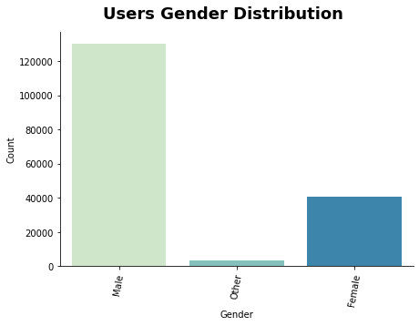

```python
graph = sb.catplot(data = df_clean, x = 'member_gender', kind = 'count', aspect = 1.8 , palette='GnBu');
graph.fig.set_size_inches(6,4)
graph.set_axis_labels('Gender','Count'),
graph.fig.suptitle('Users Gender Distribution', y = 1.07, fontsize = 18, fontweight = 'bold');
graph.set_xticklabels(rotation=80)
plt.savefig('vis1.png',dpi=80, bbox_inches = "tight")
plt.show()
```

The graph shows that most of the users are males.

#### Users Age Ditsribution

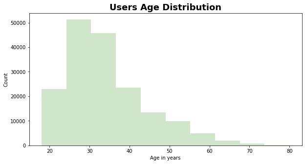

```python
plt.figure(figsize=[10, 5])
plt.hist(data = df_clean, x = 'member_age' , color='#cfe6ca')
plt.title('Users Age Distribution',fontsize=18 , fontweight = 'bold')
plt.xlabel('Age in years')
plt.ylabel('Count')
plt.savefig('vis2.png',dpi=80, bbox_inches = "tight")
plt.show()
```

The histgram shows that most of the users are between 20s and 40s.

#### Users type Ditsribution

[figure not shown]

```python
color = ['#84c1bc','#3d85ab']
explode = (0, 0.1)
plt.pie(df_clean['user_type'].value_counts(), labels = df_clean['user_type'].unique(),explode=explode, startangle = 90 , autopct='%.2f', radius=1.25, colors=color )
plt.title('User Type Distribution', fontsize=18, y=1.18 , fontweight = 'bold')
plt.savefig('vis3.png',dpi=80, bbox_inches = "tight")
plt.show()
```

#### Start Hour Distribution

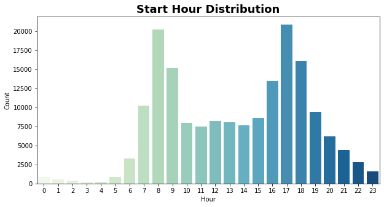

```python
ord = np.arange(0,24)

plt.figure(figsize=(10,5))
sb.countplot(data=df_clean, x='start_hour', order=ord, palette='GnBu')
plt.title('Start Hour Distribution',fontsize=18 , fontweight = 'bold')
plt.xlabel('Hour')
plt.ylabel('Count')
plt.savefig('vis4.png',dpi=80, bbox_inches = "tight")
plt.show()
```

The graph shows that the hours with the highest trips are 8 and 17.

#### Start Day Distribution

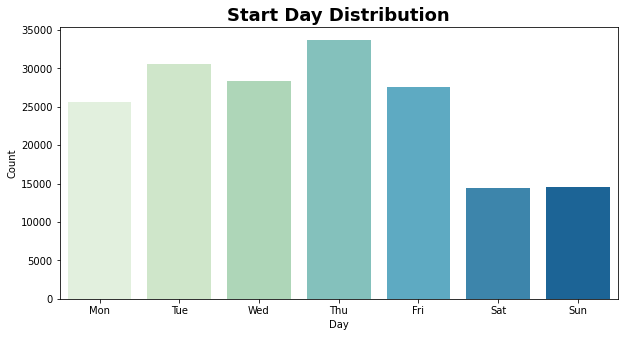

```python
plt.figure(figsize=(10,5))
sb.countplot(data=df_clean, x='start_day', palette='GnBu',order=['Mon','Tue','Wed','Thu','Fri','Sat','Sun'])
plt.title('Start Day Distribution',fontsize=18 , fontweight = 'bold')
plt.xlabel('Day')
plt.ylabel('Count')
plt.savefig('vis5.png',dpi=80, bbox_inches = "tight")
plt.show()
```

The graph shows that the days with the highest trips are Thursday and Tuesday.

#### Trip Duration Ditsribution

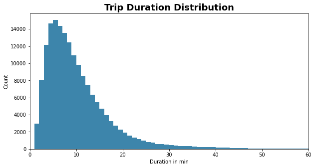

```python
bins = np.arange(0, df_clean['duration_min'].max()+2, 1)
plt.figure(figsize=(10,5))
plt.hist(data = df_clean, x = 'duration_min', bins = bins , color='#3d85ab')
plt.xlim((0, 60))
plt.title('Trip Duration Distribution',fontsize=18 , fontweight = 'bold')
plt.ylabel('Count')
plt.xlabel('Duration in min')
plt.savefig('vis6.png',dpi=80, bbox_inches = "tight")
plt.show()
```

The most frequent trip duration ranges from 5 to 9 minutes.

### Of the features you investigated, were there any unusual distributions? Did you perform any operations on the data to tidy, adjust, or change the form of the data? If so, why did you do this?

> - The age attribute had some outliers that may change the distribution, so I restricted the age range to be between 18-80.

### Bivariate Exploration

> This step involves the studying of two variables in order to discover the relationship between them.

#### Trips distribution based on start day for each type

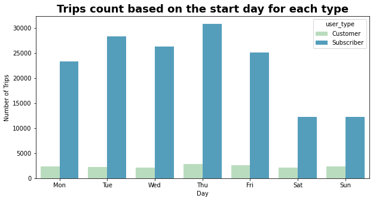

```python
plt.figure(figsize=(10,5))
sb.countplot(data = df_clean, x = 'start_day', hue = 'user_type', palette='GnBu',order=['Mon','Tue','Wed','Thu','Fri','Sat','Sun'])
plt.title('Trips count based on the start day for each type', fontsize=18, fontweight='bold')
plt.ylabel('Number of Trips')
plt.xlabel('Day')
plt.savefig('vis7.png',dpi=80, bbox_inches = "tight")
plt.show()
```

The graph above shows that most trips subscribers take place during work days then decrease in the weekend. On the other hand, customers keep a consistent pattern during all weekdays ranging from 1 to 3000 trips.

#### Trips duration based on age

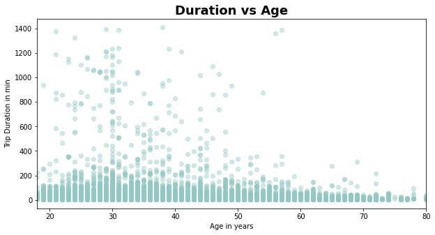

```python
plt.figure(figsize=(10,5))
plt.scatter(data = df_clean, x = 'member_age', y = 'duration_min', alpha = 0.4 , color='#92c8c4')
plt.title('Duration vs Age',fontsize=18, fontweight='bold');
plt.ylabel('Trip Duration in min')
plt.xlabel('Age in years')
plt.xlim(18, 80)
plt.savefig('vis8.png',dpi=80, bbox_inches = "tight")
plt.show()
```

Clearly, I can observe that users between 24-39 have the highest duration and it decreases as they age.

#### Average trip duration per starting hour

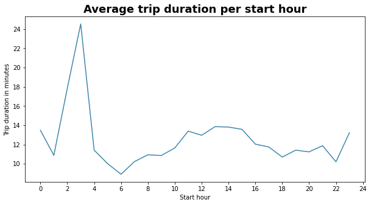

```python
df_clean.groupby('start_hour')['duration_min'].mean().plot(kind='line', figsize=(10,5) ,color='#3d85ab')
plt.title('Average trip duration per start hour' , fontsize=18 , fontweight='bold')
plt.ylabel('Trip duration in minutes')
plt.xlabel('Start hour')
plt.xticks([x for x in range(0,25, 2)])
plt.yticks(rotation=360);
plt.savefig('vis9.png',dpi=80, bbox_inches = "tight")
plt.show()
```

The graph above shows that the duartion increases when the trip start hour is between 1-3.

### Talk about some of the relationships you observed in this part of the investigation. How did the feature(s) of interest vary with other features in the dataset?

> The relationship between the trip duration and age is intresting especially because it shows how the duration decreases with age. Also, I was surprised By the relationship between the start hour and duration; I did not expect that the duration increases in such early hours!

### Did you observe any interesting relationships between the other features (not the main feature(s) of interest)?

> No, I did not find anything noticable. It needs further analysis.

### Multivariate Exploration

> This step is more complex since it involves studying and analysis of three or more variables to observe relationships.

#### Average trip duration per day

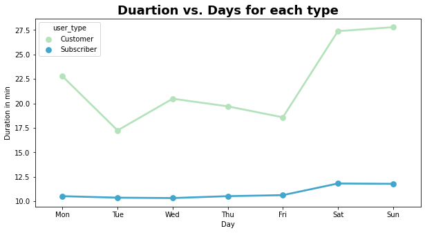

```python
plt.figure(figsize=(10,5))
sb.pointplot(data = df_clean, x = 'start_day', y = 'duration_min', hue = 'user_type', palette = 'GnBu', ci=None , order=['Mon','Tue','Wed','Thu','Fri','Sat','Sun'])
plt.title('Duartion vs. Days for each type' , fontsize=18 , fontweight='bold')
plt.ylabel('Duration in min')
plt.xlabel('Day')
plt.savefig('vis10.png',dpi=80, bbox_inches = "tight")
plt.show()
```

In the previous step I analyzed the relationship between the day and user type and observed that thrusday is the day with the highest trips demand from the subscribers, while customers showed a consistent pattern over the days. In addition, I wanted to discover if the day affects trip duration for each type. As I can see from the graph above, the subscribers' trip duration is almost the same during the work days and increases a little during the weekend. On the other hand, cutomers' trip duration shows inconsistent pattern wwhere it decreases during the work days and increases dramatically during the weekend.

#### Trip duration and age relation based on gender

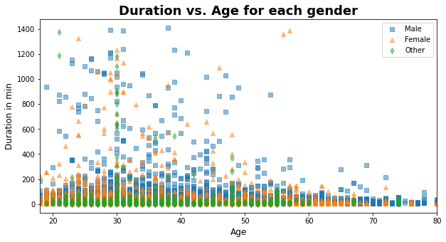

```python
#REF: https://github.com/dkhundley/ford-gobike-analysis/blob/master/ford-gobike-exploration.ipynb

plt.figure(figsize = (10,5))

cat_markers = [['Male', 's'],['Female', '^'],['Other', 'd']]

for cat, marker in cat_markers:
    df_gender = df_clean[df_clean['member_gender'] == cat]
    plt.scatter(data = df_gender, x = 'member_age', y = 'duration_min', marker = marker, alpha = .5);

plt.legend(['Male', 'Female', 'Other']);
plt.title('Duration vs. Age for each gender', fontsize = 18, fontweight='bold');
plt.xlabel('Age',fontsize = 12);
plt.xlim(18, 80);
plt.ylabel('Duration in min',fontsize = 12);
plt.savefig('vis11.png',dpi=80, bbox_inches = "tight")
plt.show()
```

I decided to perform further analysis on the trip duartion and age relationship by studying it based on the gender. I used gender ditnictive markers to determine how trip duration changes through different ages across genders.

As I previously stated that the duration decreases as they get old and this is clearly for all genders. But in term of longitivity as getting older I can see that there is a small difference between males and (females and others) in which males tend to have a slightly higher longitivity.